# PHYS_434HW2

1) A little introductory brain teaser. Which is more probable when rolling 2 six-sided dice: rolling snake eyes (two ones) or rolling sevens (dice sum to seven)? What is the ratio of the probabilities?

Rolling two one's should be (1/6)^2, cooresponding to a probability of $\frac{1}{36}$. Rolling two dice that sum to seven can be a combination of 1+6, 2+5, 3+4, 4+3, 5+2, 6+1 so the odds would be $\frac{6}{36}$, which is 6 times the probability of rolling snake eyes.

2) Following what we did in class show how to use the convolution operator to determine the probability of the sum of 2 six sided dice. Do both analytically (math & counting) and numerically (computer program). Beware the implicit definition of the values (x-axis on histogram).

$P_{A+B}(x) = \int P_A(z)P_B (x-z)dz = P_A(x)*P_B(x)$, where $*$ is the convolution.

$ℱ\{ g(x)*h(x)\} = ℱ\{g(x)\} \cdot ℱ\{h(x)\}$, where $ℱ\{\text{pdf}(x)\}$ is the characteristic function, and $ℱ$ is the Fourier transform. Note: multiplied, not dotted.

Analytically, the sum simply changes by one as the dice add up. It starts with snake eyes, as previously stated, with a (1/6)^2 probability.

$1+1 \rightarrow \frac{1}{36}$

$1+2, 2+1 \rightarrow \frac{2}{36}$

$1+3, 2+2, 3+1 \rightarrow \frac{3}{36}$

$1+4, 2+3, 3+2, 4+1 \rightarrow \frac{4}{36}$

$1+5, 2+4, 3+3, 4+2, 5+1 \rightarrow \frac{5}{36}$

$1+6, 2+5, 3+4, 4+3, 5+2, 6+1 \rightarrow \frac{6}{36}$

$2+6, 3+5, 4+4, 5+3, 6+2 \rightarrow \frac{5}{36}$

$3+6, 4+5, 5+4, 6+3 \rightarrow \frac{4}{36}$

$4+6, 5+5, 6+4 \rightarrow \frac{3}{36}$

$5+6, 6+5 \rightarrow \frac{2}{36}$

$6+6 \rightarrow \frac{1}{36}$

Below is a snippit I did from matlab, becuase I can't figure out how to use np.convolve properly in jupyter notebook, but I hate working in matlab!

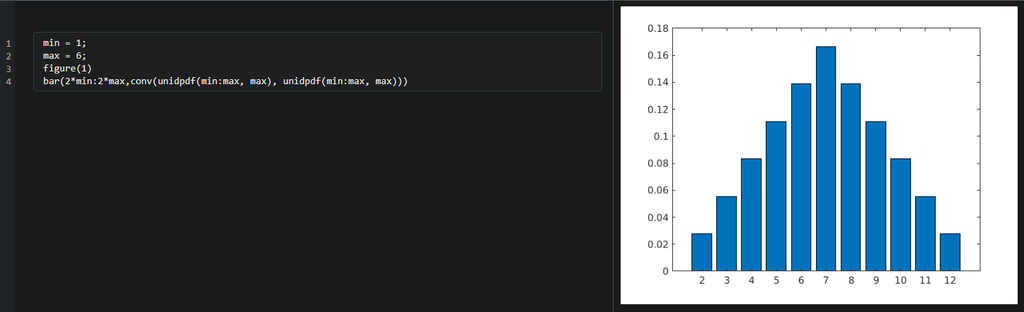

```python
from IPython.display import Image
Image(filename='Capture8.PNG')
```

3) Calculate the mean and the variance of the distribution in problem 2. Hint: this is surprisingly tricky, make sure your result makes sense.

$\text{Var}(X) = \left[X^{2}\right]-\operatorname {E} [X]^{2}$

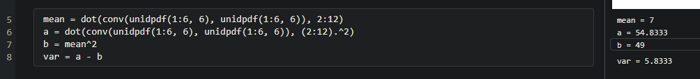

```python
from IPython.display import Image
Image(filename='Capture9.PNG')
```

4) Repeat 2, and graph the average of 10 dice. Is this is a Gaussian distribution? Explain in depth.

While it appears to be a Gaussian distribution by it's shape, it's ultimately a discrete distribution, whereas Gaussian distributions are continuous,

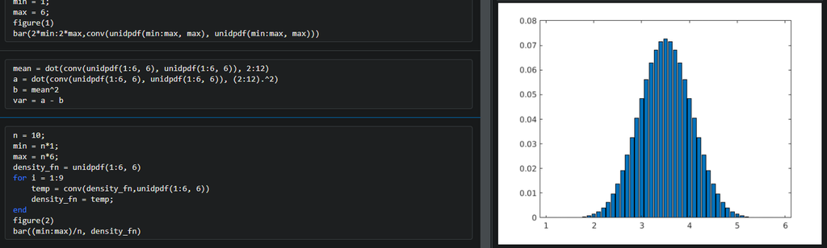

```python
from IPython.display import Image
Image(filename='Capture10.PNG')
```

Unfortunately, I can't figure out how to do #5. :(